### *This sample code was produced as part of an interview process in early 2020. It consists of two question parts.

# Part 1

### Question

1. Implement three different planning agents for solving the tower of Hanoi:
   - Agent 0 plans h steps ahead, and then chooses the plan for which the state after h steps is most similar to the final goal (where similarity is measured by the number of disks that are on the same peg in both states).
   - Agent 1 first sets the subgoal to move the largest misplaced disk to its target location and then plans h steps ahead to try to find a way how to accomplish that subgoal. The agent then executes the best plan it could find. Once the subgoal is accomplished the agent repeats its cycle of goal-setting, planning, and plan execution until all disks are in their target locations.
   - Agent 2 is identical to Agent 1 except that it sets its subgoal by resolving to move a randomly selected disk to its target location.
2. Simulate how well the three agents perform at transforming one randomly chosen initial arrangement of the disks into a) a tower in a random location, or b) another randomly chosen configuration. Repeat this simulation for different values of h.
3. For each agent plot its average performance as a function of its planning horizon h and interpret your findings.

---

In this first part of the assignment, I implement and compare the performances of three agents for solving the well-known Tower of Hanoi puzzle.

This puzzle consists of several disks of different sizes and several pegs. The disks are initially distributed to the pegs randomly, forming a random state. They can be moved to other pegs as well. However, there is a constraint: a larger disk can never be placed on top of a smaller disk at any time. The main goal is to move all the disks, in correct order (largest one at the bottom and gradually decreasing in size), into one peg to form a tower.

In the question text, three agents are described:

> **Agent 0**: Given an initial state, it calculates all possible moves after *h* disks are moved. It picks the combination that resembles the goal the most.

> **Agent 1**: Similar to Agent 0, it calculates all possible moves after *h* disks are moved from the initial state. But its selection algorithm is different. First, it compares the initial state with the goal and detects all misplaced disks. Among all the misplaced disks, it sets moving the largest one to its goal peg as a subgoal. Accordingly, its selection algorithm picks the state that resembles this subgoal the most. Unlike Agent 0, it doesn't stop at this point. From the current state, it reiterates all the steps (to calculate all possible moves after *h* disks are moved, detect the misplaced disks, set moving the largest disk to its goal peg as subgoal, and finally pick the state that resembles this subgoal the most) until all disks are moved to their respective goal pegs.

> **Agent 2**: Agent 2 executes similar to Agent 1. The only difference is about setting the subgoal. After detecting all misplaced disks, it randomly selects a disk to move to its respective goal peg as the subgoal. Similar to Agent 1, it reiterates its algorithm until all disks are moved to their goal pegs.

When I first read about the algorithms of the agents, intuitively I guessed the following: Agent 0 performs well under complete randomness, but may get stuck if smaller disks are already at the correct peg while larger ones are not. Also, its performance will be highly dependent to the *h*-value. Moving the largest misplaced item to the goal first feels like a wise move, hence, in my opinion the Agent 1 will perform best. Finally, the performance of Agent 2 will approximate to the performance of Agent 1. Randomness may work well for small problem sets. But, as the problem gets larger with more pegs and especially more disks, it will struggle to find the correct solution.

However, intuition has no place in science. We need a systematic methodology to evaluate the performances. In the following subsections, first I present the code. Then, I demonstrate how the agents work with a sample run (toy example). Finally, I run the simulations on four different topologies and present the results with plots and statistical analysis.

## The Code

```python
# import required libraries

import random
import copy
import time
import matplotlib.pyplot as plt
import scipy.stats as st
from tabulate import tabulate
import warnings

warnings.filterwarnings('ignore')
```

```python
def randomTower():
  '''
  creates a tower including all disks at a randomly selected peg
  @return the tower
  '''

  tower = []

  # select a random peg as the goal
  pegID = random.randint(0, numberOfPegs - 1)

  # create the tower
  for i in range(numberOfPegs):
    if i == pegID:
      tower.append([i for i in range(numberOfDisks, 0, -1)])
    else:
      tower.append([])

  return tower


def printHanoi(state):
  '''
  prints a state in a graphical-like output
  @param state: the state to be represented
  '''

  temp = copy.deepcopy(state)

  # create the representation of an empty row in a peg
  emptyRow = ' ' * (numberOfDisks-1) + '|' + ' ' * numberOfDisks


  for i in range(numberOfDisks+1,0,-1):

    row = ''
    # iterate over each peg and add its information to the row
    for j in range(numberOfPegs):
      # if the peg does not have a disk at this level, append an empty row
      if len(temp[j]) < i:
        row += emptyRow
      else:
        # print a disk shape according to its size
        disk = temp[j].pop()
        for k in range(numberOfDisks-disk):
          row += ' '
        for k in range(disk):
          row += '- '
        for k in range(numberOfDisks-disk):
          row += ' '

    print(row)


def calculateSimilarity(goal, state):
  '''
  calculates the similarity between a goal and a state. the similarity is the
  number of disks that are at the same peg in both goal and state.
  @param goal: the goal we are trying to reach
  @param state: the current state
  @return the similarity value
  '''
  similarity = 0

  # iterate over each peg in the goal
  for index, goalPeg in enumerate(goal):
    # for each disk in this peg, check whether the current state contains it
    # if so, increase similarity by one
    for g in goalPeg:
      if g in state[index]:
        similarity+=1

  return similarity


def randomState():
  '''
  creates a random state. it is used for initializing the problem.
  @return the created state
  '''
  # initially create the pegs empty
  state = [[] for i in range(numberOfPegs)]

  # then randomly locate the disks
  for i in range(numberOfDisks, 0, -1):
    state[random.randint(0, numberOfPegs - 1)].append(i)

  return state


def calculateOneStep(state):
  '''
  calculates all possible states that can be achieved with a single step from
  the provided state.
  @param state: the current state
  @return all possible states
  '''

  allPossibleSteps = []

  # iterate over each peg
  for i in range(numberOfPegs):
    # if the peg contains disks
    if state[i]:
      # iterate over each peg
      for j in range(numberOfPegs):
        # do not compare with the same peg
        if i == j:
          continue

        # if this peg's disk is larger than other peg's disk
        # then skip
        if state[j] and state[i][-1] > state[j][-1]:
          continue

        # otherwise, move the disk to the other peg
        temp = copy.deepcopy(state)
        temp[j].append(temp[i].pop())

        # append the obtained state to the possible steps list
        allPossibleSteps.append(temp)

  return allPossibleSteps


def lookHStepsAhead(state, horizon):
  '''
  takes the current state and the h-value as parameters and
  plans h steps into the future.
  @param state: the current state
  @param horizon: the h-value
  @return all possible states
  '''

  currentIteration = []
  future = []

  # from the current state, calculate one step into the future
  oneStepFurther = calculateOneStep(state)
  # add these states to both current iteration and all possibilities lists
  for item in oneStepFurther:
    currentIteration.append(item)
    future.append(item)

  nextIteration = []

  # do the following until h-steps are complete
  for step in range(horizon-1):
    # process each state in the current iteration separately
    for item in currentIteration:
      # for each state, calculate one step into the future
      oneStepFurther = calculateOneStep(item)
      # add the states in the future into the next iteration's list
      # and all possibilities list
      for newItem in oneStepFurther:
        # no duplicates
        if newItem not in nextIteration:
          nextIteration.append(newItem)

        # no duplicates
        if newItem not in future:
          future.append(newItem)

    # after all the states are processed in the current iteration
    # update current iteration with the contents of the next iteration list
    currentIteration = copy.deepcopy(nextIteration)
    nextIteration = []

  return future


def findMisplacedDisks(goal, state):
  '''
  takes the goal and the current state as parameter
  finds and returns all misplaced disks in ascending order
  @param goal: the goal
  @param state: the current state
  @return a list of misplaced disks in ascending order
  '''

  misplacedDisks = []

  # iterate over each peg in the goal
  for index, goalPeg in enumerate(goal):
    # for each disk in this peg, check whether the current state contains it
    # if not, append it to the list of misplaced disks
    for g in goalPeg:
      if g not in state[index]:
        misplacedDisks.append(g)

  return sorted(misplacedDisks)


def createMisplacedSubgoal(goal, state, largest = True):
  '''
  creates a subgoal.
  @param goal: the goal
  @param state: the current state
  @param largest: a boolean variable to indicate whether we are trying to
                  locate the largest mismatched disk (True), or a random one (False)
                  as the subgoal
  @return the created subgoal and this subgoal's similarity with the goal
  '''

  # first, find the list of misplaced disks
  misplacedDisks = findMisplacedDisks(goal, state)

  # check the 'largest' parameter
  # if it is True, then set the last item (largest) of the misplaced disks as target
  # otherwise, randomly select a misplaced disk as the target
  if largest:
    targetDisk = misplacedDisks[-1]
  else:
    targetDisk = random.choice(misplacedDisks)

  # initially create the subgoal as an empty state
  subgoal = [[] for i in range(numberOfPegs)]

  # create the list of correctly placed disks and append the target into this list
  correctlyPlacedDisks = [i for i in range(1, numberOfDisks+1) if i not in misplacedDisks]
  correctlyPlacedDisks.append(targetDisk)

  # iterate over the pegs of the goal
  # insert all correctly placed disks into the subgoal state
  for index, goalPeg in enumerate(goal):
    for g in goalPeg:
      if g in correctlyPlacedDisks:
        subgoal[index].append(g)

  return subgoal, len(correctlyPlacedDisks)
```

```python
def runAgent0(mainGoal, initialState, horizon, verbose=False):
  '''
  implementation of the Agent 0.
  @param mainGoal: the main goal (state) that we are trying to reach
  @param initialState: the initial state that the agent will begin its search
  @param horizon: the h-value
  @param verbose: a boolean variable for detailed outputs
  @return the state that Agent 0 selects as the solution, its similarity with
          the main goal, and its execution time
  '''

  # start stopwatch - tick tock, tick tock
  start = time.time()

  # first, copy the initial state into current state variable
  currentState = copy.deepcopy(initialState)

  # find all possible states after h-steps
  future = lookHStepsAhead(currentState, horizon)

  selectedStateSimilarity = -1
  selectedNextState = []

  # analyze each possible state separately and find the state having largest
  # similarity value with the main goal
  for item in future:
    similarity = calculateSimilarity(mainGoal, item)
    if similarity > selectedStateSimilarity:
      selectedStateSimilarity = similarity
      selectedNextState = copy.deepcopy(item)

      # if 'verbose' parameter is set to True, print the state
      if verbose:
        print("Possible next state:")
        printHanoi(selectedNextState)
        print()

  # stop stopwatch
  executionTime = time.time() - start

  return selectedNextState, selectedStateSimilarity, executionTime
```

```python
def runAgent1(mainGoal, initialState, horizon, verbose=False):
  '''
  implementation of the Agent 1.
  @param mainGoal: the main goal (state) that we are trying to reach
  @param initialState: the initial state that the agent will begin its search
  @param horizon: the h-value
  @param verbose: a boolean variable for detailed outputs
  @return the state that Agent 1 selects as the solution, its similarity with
          the main goal, and its execution time
  '''

  # start stopwatch - tick tock, tick tock
  start = time.time()

  # first, copy the initial state into current state variable
  currentState = copy.deepcopy(initialState)

  # save the results of the two previous iterations
  # in case the agent cannot achieve the subgoal with
  # the provided h-value and gets stuck
  previousFuture = None
  previousPreviousFuture = None
  counter = 0

  selectedStateSimilarity = numberOfDisks

  # do the following as long as misplaced disks exist
  while findMisplacedDisks(mainGoal, currentState):

    # create the subgoal to move the LARGEST misplaced disk into its goal peg
    subgoal, subgoalSize = createMisplacedSubgoal(mainGoal, currentState, True)

    # if 'verbose' parameter is set to True, print the current state and subgoal
    if verbose:
      print("Current state:")
      printHanoi(currentState)
      print()

      print("Subgoal:")
      printHanoi(subgoal)
      print()

    # find all possible states after h-steps
    future = lookHStepsAhead(currentState, horizon)

    selectedStateSimilarity = -1
    selectedNextState = []

    # analyze each possible state separately and find the state having largest
    # similarity value with the subgoal as the next state
    for item in future:
      similarity = calculateSimilarity(subgoal, item)
      if similarity > selectedStateSimilarity:
        selectedStateSimilarity = similarity
        selectedNextState = copy.deepcopy(item)

    # update the current state with the selected next state
    currentState = copy.deepcopy(selectedNextState)

    # check if the possible states are exactly same with the possible states of
    # the two previous iterations and update the counter value accordingly
    if (previousFuture and sorted(previousFuture) == sorted(future)) or \
    (previousFuture and previousPreviousFuture and sorted(previousPreviousFuture) == sorted(previousFuture)) or \
    (previousPreviousFuture and sorted(previousPreviousFuture) == sorted(future)):
      counter += 1
    else:
      counter = 0

    # if the possible state lists remain unchanged for 10 consecutive iterations
    # Agent 1 decides that it cannot solve the puzzle and quits
    if counter == 10:
      if verbose:
        print("Cannot improve current state. Exiting.")

      break

    # save the states in the previousFuture variable into previousPreviousFuture
    # variable, then the recently processed states into previousFuture variable
    if previousFuture:
      previousPreviousFuture = copy.deepcopy(previousFuture)
    previousFuture = copy.deepcopy(future)

  # stop stopwatch
  executionTime = time.time() - start

  return currentState, calculateSimilarity(mainGoal, currentState), executionTime
```

```python
def runAgent2(mainGoal, initialState, horizon, verbose=False):
  '''
  implementation of the Agent 2.
  @param mainGoal: the main goal (state) that we are trying to reach
  @param initialState: the initial state that the agent will begin its search
  @param horizon: the h-value
  @param verbose: a boolean variable for detailed outputs
  @return the state that Agent 2 selects as the solution, its similarity with
          the main goal, and its execution time
  '''

  # start stopwatch - tick tock, tick tock
  start = time.time()

  # first, copy the initial state into current state variable
  currentState = copy.deepcopy(initialState)

  # save the results of the two previous iterations
  # in case the agent cannot achieve the subgoal with
  # the provided h-value, and gets stuck
  previousFuture = None
  previousPreviousFuture = None
  counter = 0

  selectedStateSimilarity = numberOfDisks

  # do the following as long as misplaced disks exist
  while findMisplacedDisks(mainGoal, currentState):

    # create the subgoal to move a RANDOM misplaced disk into its goal peg
    subgoal, subgoalSize = createMisplacedSubgoal(mainGoal, currentState, False)

    # if 'verbose' parameter is set to True, print the current state and subgoal
    if verbose:
      print("Current state:")
      printHanoi(currentState)
      print()

      print("Subgoal:")
      printHanoi(subgoal)
      print()

    # find all possible states after h-steps
    future = lookHStepsAhead(currentState, horizon)

    selectedStateSimilarity = -1
    selectedNextState = []

    # analyze each possible state separately and find the state having largest
    # similarity value with the subgoal as the next state
    for item in future:
      similarity = calculateSimilarity(subgoal, item)
      if similarity > selectedStateSimilarity:
        selectedStateSimilarity = similarity
        selectedNextState = copy.deepcopy(item)

    # update the current state with the selected next state
    currentState = copy.deepcopy(selectedNextState)

    # check if the possible states are exactly same with the possible states of
    # the two previous iterations and update the counter value accordingly
    if (previousFuture and sorted(previousFuture) == sorted(future)) or \
     (previousFuture and previousPreviousFuture and sorted(previousPreviousFuture) == sorted(previousFuture)) or \
     (previousPreviousFuture and sorted(previousPreviousFuture) == sorted(future)):
      counter += 1
    else:
      counter = 0

    # if the possible state lists remain unchanged for 10 consecutive iterations
    # Agent 2 decides that it cannot solve the puzzle and quits
    if counter == 10:
      if verbose:
        print("Cannot improve current state. Exiting.")

      break

    # save the states in the previousFuture variable into previousPreviousFuture
    # variable, then the recently processed states into previousFuture variable
    if previousFuture:
      previousPreviousFuture = copy.deepcopy(previousFuture)
    previousFuture = copy.deepcopy(future)

  # stop stopwatch
  executionTime = time.time() - start

  return currentState, calculateSimilarity(mainGoal, currentState), executionTime
```

## Toy example

In this section, I present a sample run of all three agents with verbose outputs. In this sample, there are 4 pegs and 5 disks. All the agents can plan 4 steps ahead.

Below, I set the sample goal and the initial state. The similarity at the initial state is 0, which means that none of the disks are located at their goal peg. Then, I execute Agent 0, Agent 1, and Agent 2, in respective order.

```python
# this toy example consists of 4 pegs and 5 disks.
# the h-value is set to 4.

numberOfDisks = 5
numberOfPegs = 4
horizon = 4
```

```python
# main goal and initial state are chosen manually.
# initial state's similarity with the main goal is 0.

mainGoal = [[5, 4, 3, 2, 1], [], [], []]
print('Goal:\n')
printHanoi(mainGoal)
print()
print()

initialState = [[], [5, 4, 3], [2, 1], []]
print('Initial state:\n')
printHanoi(initialState)
print()

print('initial similarity = ', calculateSimilarity(mainGoal, initialState))
print()
```

```
Goal:

    |         |         |         |
    -         |         |         |
   - -        |         |         |
  - - -       |         |         |
 - - - -      |         |         |
- - - - -     |         |         |


Initial state:

    |         |         |         |
    |         |         |         |
    |         |         |         |
    |       - - -       |         |
    |      - - - -      -         |
    |     - - - - -    - -        |

initial similarity =  0
```

**Agent 0**

```python
# run Agent 0 for the toy example. print verbose output.
state, similarity, _ = runAgent0(mainGoal, initialState, horizon, verbose=True)

print("Agent 0 - Selected final state: ")
printHanoi(state)
print()
print('Final state similarity = ', similarity)
```

```
Possible next state:
    |         |         |         |
    |         |         |         |
    |         |         |         |
    |         |         |         |
    |      - - - -      -         |
  - - -   - - - - -    - -        |

Possible next state:
    |         |         |         |
    |         |         |         |
    |         |         |         |
    |         |         |         |
    -      - - - -      |         |
  - - -   - - - - -    - -        |

Possible next state:
    |         |         |         |
    |         |         |         |
    |         |         |         |
    -         |         |         |
   - -     - - - -      |         |
  - - -   - - - - -     |         |

Agent 0 - Selected final state:
    |         |         |         |
    |         |         |         |
    |         |         |         |
    -         |         |         |
   - -     - - - -      |         |
  - - -   - - - - -     |         |

Final state similarity =  3
```

**Agent 1**

```python
# run Agent 1 for the toy example. print verbose output.
state, similarity, _ = runAgent1(mainGoal, initialState, horizon, verbose=True)

print("Agent 1 - Selected final state: ")
printHanoi(state)
print()
print('Final state similarity = ', similarity)
```

```
Current state:
    |         |         |         |
    |         |         |         |
    |         |         |         |
    |       - - -       |         |
    |      - - - -      -         |
    |     - - - - -    - -        |

Subgoal:
    |         |         |         |
    |         |         |         |
    |         |         |         |
    |         |         |         |
    |         |         |         |
- - - - -     |         |         |

Current state:
    |         |         |         |
    |         |         |         |
    |         |         |         |
    |         |         |         |
    |         |         -       - - -
- - - - -     |        - -     - - - -

Subgoal:
    |         |         |         |
    |         |         |         |
    |         |         |         |
    |         |         |         |
 - - - -      |         |         |
- - - - -     |         |         |

Current state:
    |         |         |         |
    |         |         |         |
    |         |         |         |
    |         |         |         |
 - - - -      |         -         |
- - - - -   - - -      - -        |

```

[output cut: 34 more lines]

```
    -         |         |         |
   - -        |         |         |
  - - -       |         |         |
 - - - -      |         |         |
- - - - -     |         |         |

Agent 1 - Selected final state:
    |         |         |         |
    -         |         |         |
   - -        |         |         |
  - - -       |         |         |
 - - - -      |         |         |
- - - - -     |         |         |

Final state similarity =  5
```

**Agent 2**

```python
# run Agent 2 for the toy example. print verbose output.
state, similarity, _ = runAgent2(mainGoal, initialState, horizon, verbose=True)

print("Agent 2 - Selected final state: ")
printHanoi(state)
print()
print('Final state similarity = ', similarity)
```

```
Current state:
    |         |         |         |
    |         |         |         |
    |         |         |         |
    |       - - -       |         |
    |      - - - -      -         |
    |     - - - - -    - -        |

Subgoal:
    |         |         |         |
    |         |         |         |
    |         |         |         |
    |         |         |         |
    |         |         |         |
    -         |         |         |

Current state:
    |         |         |         |
    |         |         |         |
    |         |         |         |
    |       - - -       |         |
    |      - - - -      |         |
    -     - - - - -    - -        |

Subgoal:
    |         |         |         |
    |         |         |         |
    |         |         |         |
    |         |         |         |
    -         |         |         |
  - - -       |         |         |

Current state:
    |         |         |         |
    |         |         |         |
    |         |         |         |
    |         |         |         |
    -      - - - -      |         |
  - - -   - - - - -    - -        |

```

[output cut: 227 more lines]

```
    -         |         |         |
   - -        |         |         |
  - - -       |         |         |
 - - - -      |         |         |

Cannot improve current state. Exiting.
Agent 2 - Selected final state:
    |         |         |         |
    |         |         |         |
    |         |         |         |
    -         |         |         |
   - -        |         |         |
  - - -       |      - - - -  - - - - -

Final state similarity =  3
```

As seen in the verbose output, the Agent 0 can achieve a similarity value of 3 with a horizon of 4. It moves disks 1, 2, and 3 into the goal peg.

Agent 1 always tries to move the largest misplaced disk into the goal peg as a subgoal. Eventually, it manages to move all the disks into the goal peg; hence, finds the correct solution (similarity = 5).

Agent 2 tries to move a random misplaced disk into the goal peg as a subgoal. First, it tries to move disk 1 and succeeds. Next, it decides (randomly picks) to move disk 3 into the goal peg. After completing this task, it updates its subgoal to move disk 2 into the goal peg. It can, again, successfully complete this subgoal. Next subgoal is to move disk 4 into its goal peg. However, it cannot achieve this subgoal with its current state and horizon. It tries to find the solution, but cannot improve its state for 10 iterations. As a result, it terminates. Its final state similarity value is 3.

## Simulations

In this section, I run the simulations and present the outcome.

I analyze the effect of horizon selection for different topologies. The number of disks and the number of pegs affect the performance. Increasing the number of disks make the solution more complex. On average, the horizon must get larger as the number of disks increases. Increasing the number of pegs loose the stress on finding the solution, yet, the execution time increases exponentially due to the expense of calculating *h*-steps in the future with higher number of possibilities.

Accordingly, I select 4 different topologies as given (in increasing time complexity) below:

> T1) # of disks = 3, # of pegs = 3

> T2) # of disks = 6, # of pegs = 3

> T3) # of disks = 3, # of pegs = 6

> T4) # of disks = 6, # of pegs = 6

Due to the increased execution time, the maximum *h*-value analyzed for each topology differs.

The simulation runs 30 different problems at each topology. All agents are provided with the same goal and the initial state. As a result, the differences between the agents are only based upon their algorithms.

Average execution times for each agent are also plotted as a separate figure.

To elicit a reliable comparison between the agents, I also provide statistical test results for each topology. For simplicity, I prefer non-parametric tests: Friedman's test for comparing the group differences between the similarity values of agents. It is followed by a post-hoc Wilcoxon signed rank test if the difference is significant.

```python
def runSimulation(maxHValue):
  '''
  this method runs the simulations. it creates 30 different puzzles and executes
  Agents 0, 1, and 2, in respective order, for varying h-values. The h-value
  begins from 1 and increases up to the value of 'maxHValue' parameter.
  @param maxHValue: indicates the largest value of h-value
  @return obtained similarity and execution time results
  '''

  # create the empty matrices for storing the results
  similarityResults = [[[] for i in range(3)] for j in range(maxHValue)]
  executionTimeResults = [[[] for i in range(3)] for j in range(maxHValue)]
  initialSimilarities = []

  # pretty print information on running iteration number
  print('iteration #', " ".join([str(i) for i in range(1, 31)]))
  print('running     ', end="")

  # do the following for 30 times
  for iteration in range(30):

    # print a '.' for the running iteration
    if iteration < 9:
      print(".", end=" ")
    else:
      print(". ", end=" ")

    # create a random puzzle
    mainGoal = randomTower()
    initialState = randomState()

    # calculate the similarity of the initial state
    initialSimilarities.append(calculateSimilarity(mainGoal, initialState))

    # for each value between [1, maxHValue]
    # assign the value as the h-value
    for horizon in range(1, 1 + maxHValue):

      # execute Agents 0, 1, and 2, in order
      a0 = runAgent0(mainGoal, initialState, horizon)
      a1 = runAgent1(mainGoal, initialState, horizon)
      a2 = runAgent2(mainGoal, initialState, horizon)

      # store the results
      similarityResults[horizon-1][0].append(a0[1])
      similarityResults[horizon-1][1].append(a1[1])
      similarityResults[horizon-1][2].append(a2[1])
      executionTimeResults[horizon-1][0].append(a0[2])
      executionTimeResults[horizon-1][1].append(a1[2])
      executionTimeResults[horizon-1][2].append(a2[2])

  print('done!!')
  return similarityResults, executionTimeResults


def plotResults(values, maxHValue, ylabel):
  '''
  this method plots the provided results.
  @param values: similarity or execution time results returned from
                 the runSimulation() method
  @param maxHValue: indicates the largest value of h-value
  @param ylabel: the label of the y-axis in the plot
  '''

  # create the tick items for the x-axis
  h_values = [h for h in range(1, 1 + maxHValue)]

  agent0_y = []
  agent1_y = []
  agent2_y = []

  # calculate average similarity of the agents for each h-value
  for h in range(maxHValue):
    agent0_y.append(sum(values[h][0]) / len(values[h][0]))
    agent1_y.append(sum(values[h][1]) / len(values[h][1]))
    agent2_y.append(sum(values[h][2]) / len(values[h][2]))

  # create an empty figure
  fig = plt.figure()

  # write tick values into the x-axis
  plt.xticks(h_values)

  # plot the values
  plt.plot(h_values, agent0_y, '+-', label='Agent 0')
  plt.plot(h_values, agent1_y, '*-', label='Agent 1')
  plt.plot(h_values, agent2_y, '.-', label='Agent 2')

  # update the labels of both axes
  plt.xlabel("h-values")
  plt.ylabel(ylabel)

  # add a legend and show the figure
  plt.legend()
  plt.show()


def doStatisticalTests(values, maxHValue):
  '''
  applies statistical tests to the provided results.
  @param values: similarity results returned from the runSimulation() method
  @param maxHValue: indicates the largest value of h-value
  @return a table consisting of statistical test results
  '''

  result = []
  columns = ['\nh-value', 'Agent 0\nsimilarity', 'Agent 1\nsimilarity', 'Agent 2\nsimilarity', \
             '\nFriedman test', 'Wilcoxon test\nAgent 0 - Agent 1', \
             'Wilcoxon test\nAgent 0 - Agent 2', 'Wilcoxon test\nAgent 1 - Agent 2']

  for h in range(maxHValue):
    row = []
    row.append(h+1)

    # calculate average similarity of the agents for each h-value
    row.append(float("%f" % (sum(values[h][0]) / len(values[h][0]))))
    row.append(float("%f" % (sum(values[h][1]) / len(values[h][1]))))
    row.append(float("%f" % (sum(values[h][2]) / len(values[h][2]))))

    # apply Friedman test
    statistics, p_value = st.friedmanchisquare(values[h][0], values[h][1], values[h][2])

    # format the results with actual numbers only (omit NaN values)
    if p_value < 1:
      row.append("X^2=%5.2f, p=%.3f" % (statistics, p_value))

      # if the group differences are statistically significant
      # then do pairwise comparisons
      if p_value < 0.05:
        t_value_0_1, p_value_0_1 = st.wilcoxon(values[h][0], values[h][1])
        t_value_0_2, p_value_0_2 = st.wilcoxon(values[h][0], values[h][2])
        t_value_1_2, p_value_1_2 = st.wilcoxon(values[h][1], values[h][2])

        row.append("W=%5.2f, p=%.3f" % (t_value_0_1, p_value_0_1))
        row.append("W=%5.2f, p=%.3f" % (t_value_0_2, p_value_0_2))
        row.append("W=%5.2f, p=%.3f" % (t_value_1_2, p_value_1_2))
      else:
        row.extend(["-"]*3)

    else:
      row.extend(["-"]*4)

    result.append(row)

  # tabulate data for pretty print
  return tabulate(result, headers=columns, tablefmt="presto", numalign='center',
                  stralign='center', floatfmt=("2.2f", "1.2f", "1.2f", "1.2f"))
```

### Topology 1 (T1)

```python
# specify topology T1 settings and run the simulations

numberOfDisks = 3
numberOfPegs = 3
maxHValue = 15

t1SimilarityResults, t1ExecutionTimeResults = runSimulation(maxHValue)
```

```
iteration # 1 2 3 4 5 6 7 8 9 10 11 12 13 14 15 16 17 18 19 20 21 22 23 24 25 26 27 28 29 30
running     . . . . . . . . . .  .  .  .  .  .  .  .  .  .  .  .  .  .  .  .  .  .  .  .  .  done!!
```

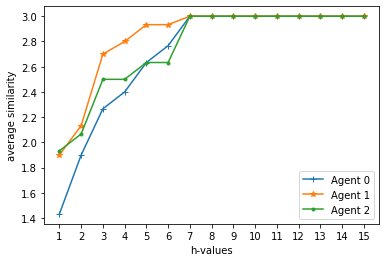

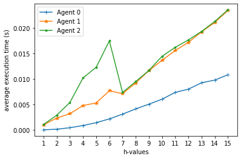

```python
# plot the results

plotResults(t1SimilarityResults, maxHValue, "average similarity")
plotResults(t1ExecutionTimeResults, maxHValue, "average execution time (s)")
```

```python
# apply statistical tests

print(doStatisticalTests(t1SimilarityResults, maxHValue))
```

| h-value | Agent 0 Similarity | Agent 1 Similarity | Agent 2 Similarity | Friedman test | Wilcoxon test Agent 0 - Agent 1 | Wilcoxon test Agent 0 - Agent 2 | Wilcoxon test Agent 1- Agent 2 |
| --- | --- | --- | --- | --- | --- | --- | --- |
| 1 | 1.43 | 1.90 | 1.93 | X^2=17.80, p=0.000 | W= 5.50, p=0.003 | W= 0.00, p=0.001 | W=12.00, p=0.705 |
| 2 | 1.90 | 2.13 | 2.07 | X^2= 6.50, p=0.039 | W=12.00, p=0.035 | W= 4.00, p=0.059 | W= 7.00, p=0.414 |
| 3 | 2.27 | 2.70 | 2.50 | X^2=14.94, p=0.001 | W=18.00, p=0.002 | W= 0.00, p=0.008 | W=11.00, p=0.058 |
| 4 | 2.40 | 2.80 | 2.50 | X^2=15.60, p=0.000 | W= 7.50, p=0.001 | W= 3.00, p=0.180 | W= 6.00, p=0.007 |
| 5 | 2.63 | 2.93 | 2.63 | X^2=12.46, p=0.002 | W= 0.00, p=0.003 | W=18.00, p=1.000 | W= 0.00, p=0.003 |
| 6 | 2.77 | 2.93 | 2.63 | X^2=10.17, p=0.006 | W= 0.00, p=0.025 | W=16.50, p=0.206 | W= 0.00, p=0.003 |
| 7 | 3.00 | 3.00 | 3.00 | - | - | - | - |
| 8 | 3.00 | 3.00 | 3.00 | - | - | - | - |
| 9 | 3.00 | 3.00 | 3.00 | - | - | - | - |
| 10 | 3.00 | 3.00 | 3.00 | - | - | - | - |
| 11 | 3.00 | 3.00 | 3.00 | - | - | - | - |
| 12 | 3.00 | 3.00 | 3.00 | - | - | - | - |
| 13 | 3.00 | 3.00 | 3.00 | - | - | - | - |
| 14 | 3.00 | 3.00 | 3.00 | - | - | - | - |
| 15 | 3.00 | 3.00 | 3.00 | - | - | - | - |

### Topology 2 (T2)

This problem is more complex as compared to the first one (T1). Here, the number of disks is increased to 6 while the number of pegs remained same at 3. Since the problem is more complex, average execution time also increases. In order to achieve more informative result, I increased the *h*-value up to 30.

The results show that none of the agents can consistently find the correct solution. However, Agents 0 and 2 consistently perform better than Agent 1. I believe the main reason for this result is the chosen performance metric: similarity. For example, Agent 0 and Agent 2 may build a state consisting of the disks 5, 2, 1 with a similarity value 3. Since Agent 1 tries to move disks in the correct order, it may struggle to move the larger disk into the goal peg; hence, less similarity than the others.

Average execution time also differentiate between the agents. Agent 0 executes fastest and Agent 2 executes slowest.

```python
# specify topology T2 settings and run the simulations

numberOfDisks = 6
numberOfPegs = 3
maxHValue = 30

t2SimilarityResults, t2ExecutionTimeResults = runSimulation(maxHValue)
```

```
iteration # 1 2 3 4 5 6 7 8 9 10 11 12 13 14 15 16 17 18 19 20 21 22 23 24 25 26 27 28 29 30
running     . . . . . . . . . .  .  .  .  .  .  .  .  .  .  .  .  .  .  .  .  .  .  .  .  .  done!!
```

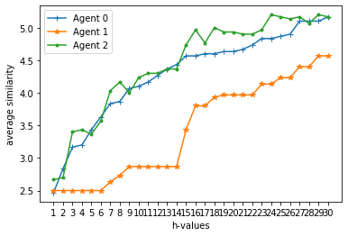

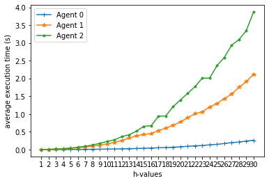

```python
# plot the results

plotResults(t2SimilarityResults, maxHValue, "average similarity")
plotResults(t2ExecutionTimeResults, maxHValue, "average execution time (s)")
```

```python
# apply statistical tests

print(doStatisticalTests(t2SimilarityResults, maxHValue))
```

| h-value | Agent 0 Similarity | Agent 1 Similarity | Agent 2 Similarity | Friedman test | Wilcoxon test Agent 0 - Agent 1 | Wilcoxon test Agent 0 - Agent 2 | Wilcoxon test Agent 1- Agent 2 |
| --- | --- | --- | --- | --- | --- | --- | --- |
| 1 | 2.47 | 2.50 | 2.67 | X^2= 5.64, p=0.060 | - | - | - |
| 2 | 2.83 | 2.50 | 2.70 | X^2=11.69, p=0.003 | W= 0.00, p=0.002 | W= 9.00, p=0.157 | W= 4.50, p=0.034 |
| 3 | 3.17 | 2.50 | 3.40 | X^2=36.59, p=0.000 | W= 0.00, p=0.000 | W= 0.00, p=0.038 | W= 0.00, p=0.000 |
| 4 | 3.20 | 2.50 | 3.43 | X^2=39.07, p=0.000 | W= 0.00, p=0.000 | W= 0.00, p=0.008 | W= 0.00, p=0.000 |
| 5 | 3.43 | 2.50 | 3.37 | X^2=34.06, p=0.000 | W= 0.00, p=0.000 | W=22.00, p=0.527 | W= 0.00, p=0.000 |
| 6 | 3.63 | 2.50 | 3.57 | X^2=35.71, p=0.000 | W= 0.00, p=0.000 | W=22.00, p=0.527 | W= 0.00, p=0.000 |
| 7 | 3.83 | 2.63 | 4.03 | X^2=46.35, p=0.000 | W= 8.50, p=0.000 | W= 0.00, p=0.014 | W= 0.00, p=0.000 |
| 8 | 3.87 | 2.73 | 4.17 | X^2=40.85, p=0.000 | W=28.50, p=0.000 | W= 3.00, p=0.030 | W= 0.00, p=0.000 |
| 9 | 4.07 | 2.87 | 4.00 | X^2=28.80, p=0.000 | W=24.00, p=0.000 | W=13.50, p=0.480 | W=33.50, p=0.000 |
| 10 | 4.10 | 2.87 | 4.23 | X^2=28.80, p=0.000 | W=22.50, p=0.000 | W=37.50, p=0.285 | W=11.00, p=0.000 |
| 11 | 4.17 | 2.87 | 4.30 | X^2=34.75, p=0.000 | W=21.00, p=0.000 | W= 3.50, p=0.102 | W= 5.00, p=0.000 |
| 12 | 4.27 | 2.87 | 4.30 | X^2=30.53, p=0.000 | W=18.00, p=0.000 | W=30.00, p=0.763 | W=19.50, p=0.000 |
| 13 | 4.37 | 2.87 | 4.37 | X^2=33.40, p=0.000 | W=13.50, p=0.000 | W=18.00, p=1.000 | W= 4.50, p=0.000 |
| 14 | 4.43 | 2.87 | 4.37 | X^2=33.80, p=0.000 | W= 7.00, p=0.000 | W=32.50, p=0.564 | W= 5.00, p=0.000 |
| 15 | 4.57 | 3.43 | 4.73 | X^2=20.66, p=0.000 | W=44.50, p=0.001 | W= 0.00, p=0.025 | W=26.00, p=0.000 |
| 16 | 4.57 | 3.80 | 4.97 | X^2=16.07, p=0.000 | W=82.00, p=0.015 | W= 0.00, p=0.006 | W=13.00, p=0.000 |
| 17 | 4.60 | 3.80 | 4.77 | X^2= 8.80, p=0.012 | W=74.50, p=0.009 | W= 0.00, p=0.025 | W=42.00, p=0.001 |
| 18 | 4.60 | 3.93 | 5.00 | X^2=12.21, p=0.002 | W=91.00, p=0.028 | W= 0.00, p=0.001 | W=29.00, p=0.002 |
| 19 | 4.63 | 3.97 | 4.93 | X^2= 8.49, p=0.014 | W=93.50, p=0.034 | W= 5.00, p=0.013 | W=45.00, p=0.004 |
| 20 | 4.63 | 3.97 | 4.93 | X^2= 8.86, p=0.012 | W=93.50, p=0.034 | W= 6.00, p=0.007 | W=41.50, p=0.003 |
| 21 | 4.67 | 3.97 | 4.90 | X^2= 6.95, p=0.031 | W=87.00, p=0.022 | W= 4.00, p=0.035 | W=50.50, p=0.004 |
| 22 | 4.73 | 3.97 | 4.90 | X^2= 7.34, p=0.025 | W=69.00, p=0.010 | W= 4.00, p=0.059 | W=45.50, p=0.002 |
| 23 | 4.83 | 4.13 | 4.97 | X^2= 2.67, p=0.263 | - | - | - |
| 24 | 4.83 | 4.13 | 5.20 | X^2= 7.65, p=0.022 | W=75.00, p=0.016 | W=14.00, p=0.008 | W=24.00, p=0.002 |
| 25 | 4.87 | 4.23 | 5.17 | X^2= 5.37, p=0.068 | - | - | - |
| 26 | 4.90 | 4.23 | 5.13 | X^2= 5.36, p=0.069 | - | - | - |
| 27 | 5.10 | 4.40 | 5.17 | X^2= 1.95, p=0.378 | - | - | - |
| 28 | 5.10 | 4.40 | 5.07 | X^2= 1.56, p=0.457 | - | - | - |
| 29 | 5.10 | 4.57 | 5.20 | X^2= 1.79, p=0.409 | - | - | - |
| 30 | 5.17 | 4.57 | 5.17 | X^2= 1.10, p=0.577 | - | - | - |

### Topology 3 (T3)

Even though solving a problem is easier in this topology, the increase in the average execution times is even more strict than T2. The reason for this increment is due to exponential increment in the number of permutations a disk can be moved into. Similar to T2, Agent 0 executes fastest and Agent 2 executes slowest.

```python
# specify topology T3 settings and run the simulations

numberOfDisks = 3
numberOfPegs = 6
maxHValue = 15

t3SimilarityResults, t3ExecutionTimeResults = runSimulation(maxHValue)
```

```
iteration # 1 2 3 4 5 6 7 8 9 10 11 12 13 14 15 16 17 18 19 20 21 22 23 24 25 26 27 28 29 30
running     . . . . . . . . . .  .  .  .  .  .  .  .  .  .  .  .  .  .  .  .  .  .  .  .  .  done!!
```

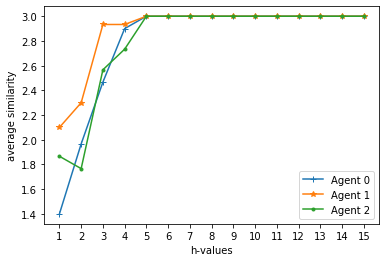

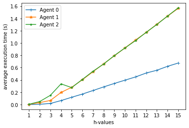

```python
# plot the results

plotResults(t3SimilarityResults, maxHValue, "average similarity")
plotResults(t3ExecutionTimeResults, maxHValue, "average execution time (s)")
```

```python
# apply statistical tests

print(doStatisticalTests(t3SimilarityResults, maxHValue))
```

| h-value | Agent 0 Similarity | Agent 1 Similarity | Agent 2 Similarity | Friedman test | Wilcoxon test Agent 0 - Agent 1 | Wilcoxon test Agent 0 - Agent 2 | Wilcoxon test Agent 1- Agent 2 |
| --- | --- | --- | --- | --- | --- | --- | --- |
| 1 | 1.40 | 2.10 | 1.87 | X^2=13.58, p=0.001 | W=35.00, p=0.002 | W= 0.00, p=0.000 | W=35.00, p=0.124 |
| 2 | 1.97 | 2.30 | 1.77 | X^2=10.97, p=0.004 | W=38.00, p=0.018 | W=11.00, p=0.058 | W=30.00, p=0.006 |
| 3 | 2.47 | 2.93 | 2.57 | X^2=20.37, p=0.000 | W= 0.00, p=0.000 | W= 8.00, p=0.257 | W= 0.00, p=0.001 |
| 4 | 2.90 | 2.93 | 2.73 | X^2= 8.86, p=0.012 | W= 0.00, p=0.317 | W= 4.00, p=0.059 | W= 0.00, p=0.014 |
| 5 | 3.00 | 3.00 | 3.00 | - | - | - | - |
| 6 | 3.00 | 3.00 | 3.00 | - | - | - | - |
| 7 | 3.00 | 3.00 | 3.00 | - | - | - | - |
| 8 | 3.00 | 3.00 | 3.00 | - | - | - | - |
| 9 | 3.00 | 3.00 | 3.00 | - | - | - | - |
| 10 | 3.00 | 3.00 | 3.00 | - | - | - | - |
| 11 | 3.00 | 3.00 | 3.00 | - | - | - | - |
| 12 | 3.00 | 3.00 | 3.00 | - | - | - | - |
| 13 | 3.00 | 3.00 | 3.00 | - | - | - | - |
| 14 | 3.00 | 3.00 | 3.00 | - | - | - | - |
| 15 | 3.00 | 3.00 | 3.00 | - | - | - | - |

### Topology 4 (T4)

This is the hardest problem within this study. The number of disks and pegs are set to 6. Accordingly, average execution times increased enormously, especially for Agent 2: an iteration takes more than a minute for an *h*-value of 5. Therefore, I increased the *h*-value up to 5 only.

The obtained results indicate with high significance that Agent 1 performs better than the other two agents, Agent 0 and Agent 2, for the *h*-values larger than 2. Due to the high execution time, we cannot determine whether this situation changes at a higher *h*-value. I can only guess that, all agents will be able to find the solution after a specific *h*-value.

```python
# specify topology T4 settings and run the simulations

numberOfDisks = 6
numberOfPegs = 6
maxHValue = 5

t4SimilarityResults, t4ExecutionTimeResults = runSimulation(maxHValue)
```

```
iteration # 1 2 3 4 5 6 7 8 9 10 11 12 13 14 15 16 17 18 19 20 21 22 23 24 25 26 27 28 29 30
running     . . . . . . . . . .  .  .  .  .  .  .  .  .  .  .  .  .  .  .  .  .  .  .  .  .  done!!
```

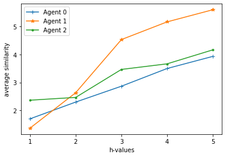

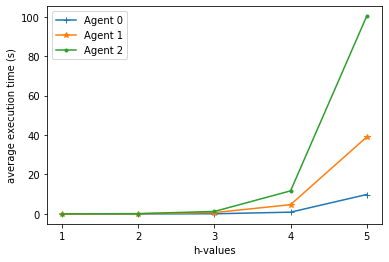

```python
# plot the results

plotResults(t4SimilarityResults, maxHValue, "average similarity")
plotResults(t4ExecutionTimeResults, maxHValue, "average execution time (s)")
```

```python
# apply statistical tests

print(doStatisticalTests(t4SimilarityResults, maxHValue))
```

| h-value | Agent 0 Similarity | Agent 1 Similarity | Agent 2 Similarity | Friedman test | Wilcoxon test Agent 0 - Agent 1 | Wilcoxon test Agent 0 - Agent 2 | Wilcoxon test Agent 1- Agent 2 |
| --- | --- | --- | --- | --- | --- | --- | --- |
| 1 | 1.70 | 1.37 | 2.37 | X^2=23.82, p=0.000 | W=87.50, p=0.041 | W= 6.00, p=0.001 | W= 7.00, p=0.000 |
| 2 | 2.30 | 2.63 | 2.47 | X^2= 5.03, p=0.081 | - | - | - |
| 3 | 2.87 | 4.53 | 3.47 | X^2=15.41, p=0.000 | W=35.50, p=0.000 | W= 7.50, p=0.000 | W=95.00, p=0.013 |
| 4 | 3.50 | 5.17 | 3.67 | X^2=19.79, p=0.000 | W=42.00, p=0.000 | W=50.00, p=0.320 | W=68.00, p=0.001 |
| 5 | 3.93 | 5.60 | 4.17 | X^2=31.29, p=0.000 | W=21.50, p=0.000 | W=22.00, p=0.154 | W=23.50, p=0.000 |

To test my hypothesis on a future *h*-value that solves all the puzzles, I did a follow-up test: the number disks and pegs are equal to 4. This topology has a higher time complexity than T1, but a lower time complexity than T4. Hence, the puzzle's nature will be the same, but it will take less time to solve it.

The obtained results do match with the results of T1: Agent 1 outperforms other two agents for the small values of *h*. After a specific point (h > 8) all agents can consistently solve the puzzle.

This outcome supports my hypothesis for T4.

```python
# specify topology T5 (T4 follow-up) settings and run the simulations

numberOfDisks = 4
numberOfPegs = 4
maxHValue = 10

t5SimilarityResults, t5ExecutionTimeResults = runSimulation(maxHValue)
```

```
iteration # 1 2 3 4 5 6 7 8 9 10 11 12 13 14 15 16 17 18 19 20 21 22 23 24 25 26 27 28 29 30
running     . . . . . . . . . .  .  .  .  .  .  .  .  .  .  .  .  .  .  .  .  .  .  .  .  .  done!!
```

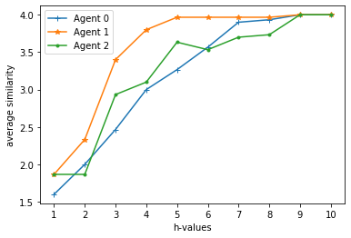

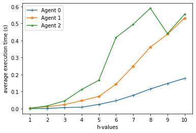

| h-value | Agent 0 Similarity | Agent 1 Similarity | Agent 2 Similarity | Friedman test | Wilcoxon test Agent 0 - Agent 1 | Wilcoxon test Agent 0 - Agent 2 | Wilcoxon test Agent 1- Agent 2 |
| --- | --- | --- | --- | --- | --- | --- | --- |
| 1 | 1.60 | 1.87 | 1.87 | X^2= 4.13, p=0.127 | - | - | - |
| 2 | 2.00 | 2.33 | 1.87 | X^2= 3.06, p=0.217 | - | - | - |
| 3 | 2.47 | 3.40 | 2.93 | X^2=21.91, p=0.000 | W=43.00, p=0.001 | W= 0.00, p=0.000 | W=56.00, p=0.059 |
| 4 | 3.00 | 3.80 | 3.10 | X^2=30.82, p=0.000 | W= 0.00, p=0.000 | W=35.00, p=0.405 | W= 0.00, p=0.000 |
| 5 | 3.27 | 3.97 | 3.63 | X^2=30.09, p=0.000 | W= 0.00, p=0.000 | W= 7.00, p=0.002 | W= 0.00, p=0.002 |
| 6 | 3.57 | 3.97 | 3.53 | X^2=16.53, p=0.000 | W= 0.00, p=0.001 | W=42.00, p=0.782 | W= 0.00, p=0.000 |
| 7 | 3.90 | 3.97 | 3.70 | X^2=13.00, p=0.002 | W= 0.00, p=0.157 | W= 0.00, p=0.014 | W= 0.00, p=0.005 |
| 8 | 3.93 | 3.97 | 3.73 | X^2=10.75, p=0.005 | W= 0.00, p=0.317 | W= 4.50, p=0.034 | W= 0.00, p=0.008 |
| 9 | 4.00 | 4.00 | 4.00 | - | - | - | - |
| 10 | 4.00 | 4.00 | 4.00 | - | - | - | - |

```python
plotResults(t5SimilarityResults, maxHValue, "average similarity")
plotResults(t5ExecutionTimeResults, maxHValue, "average execution time (s)")
print(doStatisticalTests(t5SimilarityResults, maxHValue))
```

## Conclusion

I implemented the three agents, Agents 0, 1, and 2, and compared their performances over 4 different topologies.

In the first topology (T1), the number of disks and pegs are equal to 3. Simulations show that Agent 1 performs better for the first few *h*-values. After an *h*-value of 7, all agents can correctly solve the puzzle. The nature of the fourth topology (T4) is the same with T1, i.e. the number of disks and pegs are equal. However, T4 is more complex than T1 with respect to its higher number of disks and pegs. The obtained results are consistent with the results of T1: Agent 1 performs better for the first few *h*-values. Due to its high execution time, we cannot test it for higher *h*-values. Yet, I managed to show with a follow-up study that all agents will be able to solve the puzzle after a specific *h*-value, as similar to T1.

For the second topology (T2), the number of disks is higher than the number of pegs. As a result, the agents don't have much area to move. Accordingly, Agent 1 struggles to move towards the subgoal, i.e. moving the largest misplaced disk to its goal peg. On the other hand, the other two agents have higher chance of increasing similarity.

Finally, in the third topology (T3), the number of disks is lower than the number of pegs. Therefore, all agents can freely move the disks as they wish and solve the puzzle with small *h*-values.

In the simulations, Agents 0 and 2 performed similarly in all topologies. Agent 1 outperformed them in T1-T4 and T3, but it was outclassed in T2.

On execution times, Agent 0 always executes fastest. It is followed by Agent 1 and Agent 2, respectively.

# Part 2

### Question

*A randomized controlled trial compared 12 different variants of a goal setting app to a control condition that did wasn't given the goal setting app. The researcher recruited 50 participants per condition and used RescueTime to obtain a productivity score for each participant. The resulting data are contained in the attached csv file. How would you interpret these results?*

---

According to the question, a researcher wants to compare the performances of 12 methods against a control group. For this purpose, she recruits 50 participants for each method. This information is crucial as it indicates that the study was held over independent groups. We will select the statistical tests according to this information.

A CSV file (productivity_scores.csv) is provided. At the first glance, the file consists of 60 rows and 13 columns. The number of columns do match with the number of methods and the control group as mentioned in the question text. On the other hand, each method has 60 entries, rather than 50. I considered this mismatch as a typo in the question text and included all rows in my analysis.

The names or orders of the methods and the control group are not provided in the question text. For simplicity, I considered the last column as the control group and named every other method with an index value followed by the letter M, e.g. M1, M2, etc.

Finally, according to the question, productivity score (PS) values are obtained from RescueTime. Although a simple check on RescueTime website clearly shows that they provide PS values in the interval [0, 100], the data in the file consists of values that are larger than 100. Again, for simplicity, I did not preprocess these values, but assumed that a higher PS value indicates higher productivity.

Now, I begin my analysis on the data. For this purpose, first, I import the required libraries. Then, I load the data from the CSV file.

```python
!pip install colorama
```

```python
from colorama import Fore # for producing colored output
import pandas as pd # for loading and storing data
import scipy.stats as st # for statistical tests
```

```python
methods = ['M1', 'M2', 'M3', 'M4', 'M5', 'M6', 'M7', 'M8', 'M9', 'M10', 'M11', 'M12', 'Control']
data = pd.read_csv('productivity_scores.csv', header=None, index_col=False, names=methods)
```

Let's take a look at the data summary, i.e. basic statistical details such as mean, standard deviation, etc.

```python
data.describe()
```

|  | M1 | M2 | M3 | M4 | M5 | M6 | M7 | M8 | M9 | M10 | M11 | M12 | Control |
| --- | --- | --- | --- | --- | --- | --- | --- | --- | --- | --- | --- | --- | --- |
| count | 60.000000 | 60.000000 | 60.000000 | 60.000000 | 60.000000 | 60.000000 | 60.000000 | 60.000000 | 60.000000 | 60.000000 | 60.00000 | 60.000000 | 60.000000 |
| mean | 91.416667 | 91.783333 | 96.250000 | 95.283333 | 94.266667 | 94.000000 | 94.933333 | 91.083333 | 86.950000 | 101.933333 | 93.40000 | 93.683333 | 87.533333 |
| std | 28.396283 | 27.762975 | 32.692001 | 31.328274 | 29.420889 | 24.967776 | 29.505453 | 29.015654 | 32.450445 | 26.586518 | 28.83101 | 32.521436 | 33.463092 |
| min | 14.000000 | 30.000000 | 28.000000 | 14.000000 | 33.000000 | 27.000000 | 0.000000 | 17.000000 | 5.000000 | 46.000000 | 19.00000 | 21.000000 | 15.000000 |
| 25% | 75.000000 | 70.750000 | 71.500000 | 80.000000 | 75.500000 | 76.000000 | 78.750000 | 76.750000 | 66.500000 | 85.500000 | 74.75000 | 72.750000 | 69.750000 |
| 50% | 91.000000 | 93.500000 | 98.000000 | 92.000000 | 93.500000 | 96.000000 | 96.500000 | 93.000000 | 85.500000 | 96.000000 | 99.50000 | 88.000000 | 86.500000 |
| 75% | 109.000000 | 111.750000 | 119.500000 | 114.250000 | 113.000000 | 110.250000 | 112.500000 | 106.000000 | 109.250000 | 123.000000 | 113.25000 | 113.250000 | 113.250000 |
| max | 144.000000 | 145.000000 | 166.000000 | 180.000000 | 160.000000 | 151.000000 | 172.000000 | 193.000000 | 168.000000 | 171.000000 | 143.00000 | 168.000000 | 161.000000 |

Data summary shows similar mean and standard deviation values for most of the methods. Among the methods, M10 (101.93 ± 26.59) shows promising results. M9 (86.95 ± 32.45), on the contrary, performs worse than the Control group (87.53 ± 33.46).

At this point, we need further analysis to investigate whether any of the methods perform significantly better than the others. Since there are more than two independent groups (more specifically 13), we cannot immediately apply pairwise comparison to the results. First, we need to check whether the differences between the group means are significant.

For comparing the differences of means between more than two independent groups, we can use the one-way ANOVA parametric test. One-way ANOVA is a strong test, but it relies on the below given assumptions:

1. The samples are independent.
2. Dependent variables are approximately normally distributed for each category of the independent variable. One-way ANOVA is robust to small violations of normality, i.e. assumption can be a little violated and still provide valid results.
3. The population standard deviations of the groups are all equal. This property is known as homoscedasticity or homogeneity of variances.

The first assumption is valid for our data, since 60 participants per method were recruited. As a result, no participant in one group has data for another method; hence, samples are independent.

For the second assumption, we will use the Shapiro-Wilk test to check whether data for each method is normally distributed or not. A p-value less than 0.05 indicates that the data is NOT normally distributed.

Finally, for the third assumption, we will utilize Levene's test for equality of variances. A p-value less than 0.05 indicates that the variances of the methods are NOT equal and violates the third assumption.

If any of these assumptions are violated, we can use the non-parametric counterpart of the one-way ANOVA test, which is the Kruskal-Wallis H-test. Kruskal-Wallis H-test is not as strong as the one-way ANOVA test, yet, it provides reliable results when the mentioned assumptions are violated.

Now, let's use the Shapiro-Wilk test on each method separately to see if its data is normally distributed or not. In the output, normally distributed methods are printed in Green color. The Red color is used, otherwise.

```python
for m in methods:
score, p_value = st.shapiro(data[m])
if p_value > 0.05:
  print(Fore.GREEN + m + " (W=%.3f, p=%.3f)" % (score, p_value))
else:
  print(Fore.RED + m + " (W=%.3f, p=%.3f)" % (score, p_value))
```

```
M1 (W=0.983, p=0.560)
M2 (W=0.981, p=0.475)
M3 (W=0.986, p=0.707)
M4 (W=0.987, p=0.763)
M5 (W=0.988, p=0.798)
M6 (W=0.992, p=0.971)
M7 (W=0.975, p=0.249)
M8 (W=0.959, p=0.044)
M9 (W=0.993, p=0.979)
M10 (W=0.984, p=0.602)
M11 (W=0.948, p=0.013)
M12 (W=0.979, p=0.403)
Control (W=0.989, p=0.877)
```

According to the Shapiro-Wilk test, the data is normally distributed except for the M8 and M11 methods. We may consider this as a small violation of normality; hence, no violation of the second assumption.

Now, we will continue with the Levene's test for equality of variances. Similarly, a Green color in the output indicates equal variances, whereas a Red color indicates otherwise.

```python
score, p_value = st.levene(*[data[x] for x in methods])
if p_value > 0.05:
print(Fore.GREEN + "Levene's test for equality of variances: (F=%.3f, p=%.3f)" % (score, p_value))
else:
print(Fore.RED + "Levene's test for equality of variances: (F=%.3f, p=%.3f)" % (score, p_value))
```

```
Levene's test for equality of variances: (F=1.011, p=0.436)
```

According to the Levene's test, variances of the groups are equal; hence, no violation of the third assumption.

Since all of the assumptions hold, we will use the one-way ANOVA test to see whether the differences of means between the groups are significant or not. A p-value less than 0.05 indicates significant differences between the groups. In such a scenario, we will do posthoc analysis and apply pairwise comparison (independent t-test) to detect the source of the diffences. On the other hand, if the differences between the groups are statistically not significant, then we will conclude our analysis without pairwise comparisons.

Again, I apply a similar color-code in the output: Green for significant differences and Red for insignificant differences.

```python
score, p_value = st.f_oneway(*[data[x] for x in methods])
if p_value <= 0.05:
print(Fore.GREEN + "One-way ANOVA: (F=%.3f, p=%.3f)" % (score, p_value))
else:
print(Fore.RED + "One-way ANOVA: (F=%.3f, p=%.3f)" % (score, p_value))
```

```
One-way ANOVA: (F=0.985, p=0.461)
```

According to the one-way ANOVA test, the differences between the groups are not significant. This results tells us to conclude our analysis here, without making pairwise comparisons. Making pairwise comparisons at this point could lead us to Type I errors.

But before concluding the analysis, I wanted to test the data with the non-parametric Kruskal-Wallis H-test since there were minor violations of normality within the data.

```python
score, p_value = st.kruskal(*[data[x] for x in methods])
if p_value <= 0.05:
print(Fore.GREEN + "Non-parametric Kruskal-Wallis H-Test: (X^2=%.3f, p=%.3f)" % (score, p_value))
else:
print(Fore.RED + "Non-parametric Kruskal-Wallis H-Test: (X^2=%.3f, p=%.3f)" % (score, p_value))
```

```
Non-parametric Kruskal-Wallis H-Test: (X^2=11.177, p=0.514)
```

The Kruskal-Wallis H-test results match with the results of the one-way ANOVA test. Again, the differences between groups are not found to be significant; hence, we cannot reject the null-hypothesis.

**Therefore, we conclude the analysis by stating that none of the 12 new methods can improve the productivity score.**